# Session 8.1 KNN: Classifying iPlayer users

Dr Kanishka Bhattacharya

2021-11-17

# 1 Learning Objectives for Session 8

1. K nearest neighbors (K-NN)
   1. Basics of the algorithm
   2. When does it work?
   3. Tuning the parameters
2. Comparing different supervised algorithms
3. Introduction to ensemble methods: What is the idea behind ensemble methods?
4. Classification and regression trees (see the next rmd file)
   1. Basics of the algorithm – splitting and stopping rules
   2. Visualizing results
   3. Feature importance

# 2 Introduction

In this session we will predict the future usage in the BBC iPlayer data. Specifically, given users’ january viewing information we will predict the likelihood of using iPlayer in february. In this document the analysis focuses om the KNN method. In the next document we will use tree based methods for the same goal and then compare these methods.

This is the R Markdown document for Session 8 of AM04 Data Science course that contains all the functions and libraries we use in class as well as additional tools that we may not have time to cover. There are many questions and alternative implementations embedded in this document to facilitate your learning. Please go through these exercises to reinforce your understanding. This document is organized as follows.

**Table of Contents**

- Section 1: Learning Objectives for Session 8
- Section 2: Introduction
- Section 3: Data exploration and preprocessing
- Section 4: Fitting a logistic regression model
- Section 5: Implementing K-NN using caret library
- Section 6: A simple ensemble method
- Section 7: Fancy plots
- Section 8: Using K-NN with PCA (next week)

# 3 BBC Data

## 3.1 Preprocessing data for classification

We use the user based the data we generated last week for clustering. For this session I added the view information for each user in the second month (i.e. Feb). Spefically, I have added three more columns; numberOfShows_M2, total_Time_M2, and watched_in_M2. Let’s load and explore the data.

```r
userBasedData_raw <- read.csv(file="UserBasedData.csv",header=TRUE)


head(userBasedData_raw,2)
```

```
##   user_id noShows total_Time weekday weekend Afternoon Day Evening Night
## 1  0001c6       2 16.6792000       1       0         0   0       1     0
## 2  000c1a       2  0.3103333       1       0         0   1       0     0
##   Children Comedy Drama Entertainment Factual Learning Music News NoGenre
## 1        0      0     0             0       0        0     0  100       0
## 2        0      0     0             0       0        0     0  100       0
##   RelEthics Sport Weather per_al_Watched numberOfShows_M2 total_Time_M2
## 1         0     0       0             50                0          0.00
## 2         0     0       0              0                9        198.72
##   watched_in_M2
## 1             0
## 2             1
```

```r
glimpse(userBasedData_raw)
```

```
## Rows: 9,351
## Columns: 25
## $ user_id          <chr> "0001c6", "000c1a", "001c53", "001d44", "002b2e", "00…
## $ noShows          <int> 2, 2, 2, 1, 31, 1, 1, 1, 2, 3, 20, 1, 1, 2, 1, 1, 1, …
## $ total_Time       <dbl> 16.6792000, 0.3103333, 1.8663000, 1.0636167, 534.3555…
## $ weekday          <dbl> 1.0000000, 1.0000000, 1.0000000, 0.0000000, 0.8709677…
## $ weekend          <dbl> 0.0000000, 0.0000000, 0.0000000, 1.0000000, 0.1290323…
## $ Afternoon        <dbl> 0.000, 0.000, 0.000, 0.000, 0.000, 0.000, 0.000, 0.00…
## $ Day              <dbl> 0.00000000, 1.00000000, 1.00000000, 0.00000000, 0.096…
## $ Evening          <dbl> 1.0000000, 0.0000000, 0.0000000, 1.0000000, 0.8064516…
## $ Night            <dbl> 0.00000000, 0.00000000, 0.00000000, 0.00000000, 0.096…
## $ Children         <dbl> 0, 0, 0, 0, 0, 0, 0, 0, 0, 0, 0, 0, 0, 0, 0, 0, 0, 0,…
## $ Comedy           <dbl> 0.000000, 0.000000, 0.000000, 0.000000, 6.451613, 0.0…
## $ Drama            <dbl> 0.00000, 0.00000, 0.00000, 0.00000, 32.25806, 0.00000…
## $ Entertainment    <dbl> 0.000000, 0.000000, 0.000000, 100.000000, 6.451613, 1…
## $ Factual          <dbl> 0.00000, 0.00000, 0.00000, 0.00000, 41.93548, 0.00000…
## $ Learning         <dbl> 0, 0, 0, 0, 0, 0, 0, 0, 0, 0, 0, 0, 0, 0, 0, 0, 0, 0,…
## $ Music            <dbl> 0.000000, 0.000000, 0.000000, 0.000000, 6.451613, 0.0…
## $ News             <dbl> 100.000000, 100.000000, 100.000000, 0.000000, 3.22580…
## $ NoGenre          <dbl> 0, 0, 0, 0, 0, 0, 0, 0, 0, 0, 0, 0, 0, 0, 0, 0, 0, 0,…
## $ RelEthics        <dbl> 0.00, 0.00, 0.00, 0.00, 0.00, 0.00, 0.00, 0.00, 0.00,…
## $ Sport            <dbl> 0.000000, 0.000000, 0.000000, 0.000000, 3.225806, 0.0…
## $ Weather          <dbl> 0.00000, 0.00000, 0.00000, 0.00000, 0.00000, 0.00000,…
## $ per_al_Watched   <dbl> 50.00000, 0.00000, 0.00000, 0.00000, 22.58065, 100.00…
## $ numberOfShows_M2 <int> 0, 9, 0, 2, 0, 0, 0, 0, 2, 1, 8, 0, 0, 0, 0, 0, 1, 0,…
## $ total_Time_M2    <dbl> 0.0000000, 198.7199500, 0.0000000, 14.5477000, 0.0000…
## $ watched_in_M2    <int> 0, 1, 0, 1, 0, 0, 0, 0, 1, 1, 1, 0, 0, 0, 0, 0, 1, 0,…
```

```r
describe(userBasedData_raw)
```

```
## userBasedData_raw
##
##  25  Variables      9351  Observations
## --------------------------------------------------------------------------------
## user_id
##        n  missing distinct
##     9351        0     9351
##
## lowest : 0001c6 000c1a 001c53 001d44 002b2e, highest: ffec33 ffec4c fff1fd fffd0b ffffca
## --------------------------------------------------------------------------------
## noShows
##        n  missing distinct     Info     Mean      Gmd      .05      .10
##     9351        0      172    0.965    10.08    14.14        1        1
##      .25      .50      .75      .90      .95
##        1        3        9       25       41
##
## lowest :   1   2   3   4   5, highest: 358 488 515 521 782
## --------------------------------------------------------------------------------
## total_Time
##        n  missing distinct     Info     Mean      Gmd      .05      .10
##     9351        0     8873        1    190.6    297.9   0.2783   0.8515
##      .25      .50      .75      .90      .95
##   4.1420  39.5311 158.9661 462.8491 836.0884
##
## lowest : 8.340000e-02 8.341667e-02 8.370000e-02 8.421667e-02 8.546667e-02
## highest: 7.970077e+03 1.182949e+04 1.388036e+04 1.408559e+04 2.582220e+04
## --------------------------------------------------------------------------------
## weekday
##        n  missing distinct     Info     Mean      Gmd      .05      .10
##     9351        0      606    0.922   0.6461   0.4189   0.0000   0.0000
##      .25      .50      .75      .90      .95
##   0.3333   0.7717   1.0000   1.0000   1.0000
##
## lowest : 0.00000000 0.02941176 0.04166667 0.05263158 0.05882353
## highest: 0.96875000 0.97058824 0.97560976 0.97647059 1.00000000
## --------------------------------------------------------------------------------
## weekend
##        n  missing distinct     Info     Mean      Gmd      .05      .10
##     9351        0      606    0.922   0.3539   0.4189   0.0000   0.0000
##      .25      .50      .75      .90      .95
```

[output cut: 165 more lines]

```
## --------------------------------------------------------------------------------
## total_Time_M2
##        n  missing distinct     Info     Mean      Gmd      .05      .10
##     9351        0     5012    0.907    143.6    242.4    0.000    0.000
##      .25      .50      .75      .90      .95
##    0.000    1.351  105.877  383.841  712.856
##
## lowest : 0.000000e+00 8.786667e-02 8.941667e-02 9.028333e-02 9.156667e-02
## highest: 7.997289e+03 9.814490e+03 1.027240e+04 1.034793e+04 1.643365e+04
## --------------------------------------------------------------------------------
## watched_in_M2
##        n  missing distinct     Info      Sum     Mean      Gmd
##     9351        0        2    0.743     5119   0.5474   0.4956
##
## --------------------------------------------------------------------------------
```

## 3.2 ICE the data: Inspect, Clean, Explore

Any data science engagement starts with ICE: Inspect, Clean and Explore the data. For this workshop I have cleaned the data for you. We will look into this step in more detail in the data visualization course.

```r
head(userBasedData_raw,2)
```

```
##   user_id noShows total_Time weekday weekend Afternoon Day Evening Night
## 1  0001c6       2 16.6792000       1       0         0   0       1     0
## 2  000c1a       2  0.3103333       1       0         0   1       0     0
##   Children Comedy Drama Entertainment Factual Learning Music News NoGenre
## 1        0      0     0             0       0        0     0  100       0
## 2        0      0     0             0       0        0     0  100       0
##   RelEthics Sport Weather per_al_Watched numberOfShows_M2 total_Time_M2
## 1         0     0       0             50                0          0.00
## 2         0     0       0              0                9        198.72
##   watched_in_M2
## 1             0
## 2             1
```

```r
userBasedData_clean<- userBasedData_raw %>%
  mutate(
    watched_in_M2 = factor(watched_in_M2) # turn 'watched_in_M2' into a categorical variable
  ) %>%
  dplyr::select(-numberOfShows_M2,-total_Time_M2) %>% #So let's drop the other variables that measures february usage in other ways.
  mutate(watched_in_Feb = dplyr::recode(watched_in_M2,
                      "1" = "Yes",
                      "0" = "No"))

head(userBasedData_clean,2)
```

```
##   user_id noShows total_Time weekday weekend Afternoon Day Evening Night
## 1  0001c6       2 16.6792000       1       0         0   0       1     0
## 2  000c1a       2  0.3103333       1       0         0   1       0     0
##   Children Comedy Drama Entertainment Factual Learning Music News NoGenre
## 1        0      0     0             0       0        0     0  100       0
## 2        0      0     0             0       0        0     0  100       0
##   RelEthics Sport Weather per_al_Watched watched_in_M2 watched_in_Feb
## 1         0     0       0             50             0             No
## 2         0     0       0              0             1            Yes
```

```r
glimpse(userBasedData_clean) #take a look at the data
```

```
## Rows: 9,351
## Columns: 24
## $ user_id        <chr> "0001c6", "000c1a", "001c53", "001d44", "002b2e", "002b…
## $ noShows        <int> 2, 2, 2, 1, 31, 1, 1, 1, 2, 3, 20, 1, 1, 2, 1, 1, 1, 8,…
## $ total_Time     <dbl> 16.6792000, 0.3103333, 1.8663000, 1.0636167, 534.355566…
## $ weekday        <dbl> 1.0000000, 1.0000000, 1.0000000, 0.0000000, 0.8709677, …
## $ weekend        <dbl> 0.0000000, 0.0000000, 0.0000000, 1.0000000, 0.1290323, …
## $ Afternoon      <dbl> 0.000, 0.000, 0.000, 0.000, 0.000, 0.000, 0.000, 0.000,…
## $ Day            <dbl> 0.00000000, 1.00000000, 1.00000000, 0.00000000, 0.09677…
## $ Evening        <dbl> 1.0000000, 0.0000000, 0.0000000, 1.0000000, 0.8064516, …
## $ Night          <dbl> 0.00000000, 0.00000000, 0.00000000, 0.00000000, 0.09677…
## $ Children       <dbl> 0, 0, 0, 0, 0, 0, 0, 0, 0, 0, 0, 0, 0, 0, 0, 0, 0, 0, 0…
## $ Comedy         <dbl> 0.000000, 0.000000, 0.000000, 0.000000, 6.451613, 0.000…
## $ Drama          <dbl> 0.00000, 0.00000, 0.00000, 0.00000, 32.25806, 0.00000, …
## $ Entertainment  <dbl> 0.000000, 0.000000, 0.000000, 100.000000, 6.451613, 100…
## $ Factual        <dbl> 0.00000, 0.00000, 0.00000, 0.00000, 41.93548, 0.00000, …
## $ Learning       <dbl> 0, 0, 0, 0, 0, 0, 0, 0, 0, 0, 0, 0, 0, 0, 0, 0, 0, 0, 0…
## $ Music          <dbl> 0.000000, 0.000000, 0.000000, 0.000000, 6.451613, 0.000…
## $ News           <dbl> 100.000000, 100.000000, 100.000000, 0.000000, 3.225806,…
## $ NoGenre        <dbl> 0, 0, 0, 0, 0, 0, 0, 0, 0, 0, 0, 0, 0, 0, 0, 0, 0, 0, 0…
## $ RelEthics      <dbl> 0.00, 0.00, 0.00, 0.00, 0.00, 0.00, 0.00, 0.00, 0.00, 0…
## $ Sport          <dbl> 0.000000, 0.000000, 0.000000, 0.000000, 3.225806, 0.000…
## $ Weather        <dbl> 0.00000, 0.00000, 0.00000, 0.00000, 0.00000, 0.00000, 0…
## $ per_al_Watched <dbl> 50.00000, 0.00000, 0.00000, 0.00000, 22.58065, 100.0000…
## $ watched_in_M2  <fct> 0, 1, 0, 1, 0, 0, 0, 0, 1, 1, 1, 0, 0, 0, 0, 0, 1, 0, 1…
## $ watched_in_Feb <fct> No, Yes, No, Yes, No, No, No, No, Yes, Yes, Yes, No, No…
```

```r
userBasedData_clean<-userBasedData_clean%>%select(-watched_in_M2,-user_id) #let's drop one of the dependent variables
head(userBasedData_clean,2)
```

```
##   noShows total_Time weekday weekend Afternoon Day Evening Night Children
## 1       2 16.6792000       1       0         0   0       1     0        0
## 2       2  0.3103333       1       0         0   1       0     0        0
##   Comedy Drama Entertainment Factual Learning Music News NoGenre RelEthics
## 1      0     0             0       0        0     0  100       0         0
## 2      0     0             0       0        0     0  100       0         0
##   Sport Weather per_al_Watched watched_in_Feb
## 1     0       0             50             No
## 2     0       0              0            Yes
```

The column descriptions are as follows.

1. user_id – a unique identifier for the viewer
2. noShows – number oh shows viewed in january
3. total_Time – total time spent viewing programs on BBC iPlayer in January
4. weekday/weekend – percentage of viewing in weekday/weekend
5. Afternoon/Day/Evening/Night– percentage of viewing in Afternoon/Day/Evening/Night
6. Children/Comedy/Drama/Entertainment/Factual/Learning/Music/News/NoGenre/RelEthics/Sport/Weather – percentage of viewing in different genres
7. per_al_Watched – percentage of shows viewer watched more than 60% of
8. numberOfShows_M2 – number of shows viewed in february
9. total_Time_M2 - total time spent viewing programs on BBC iPlayer in February
10. watched_in_M2 - equals 1 if user viewed a program in February

```r
userBasedData_clean %>%
  skimr::skim() #skim function provides more detailed summary of the data
```

Data summary

| Name | Piped data |
| --- | --- |
| Number of rows | 9351 |
| Number of columns | 22 |
| _______________________ |  |
| Column type frequency: |  |
| factor | 1 |
| numeric | 21 |
| ________________________ |  |
| Group variables | None |

**Variable type: factor**

| skim_variable | n_missing | complete_rate | ordered | n_unique | top_counts |
| --- | --- | --- | --- | --- | --- |
| watched_in_Feb | 0 | 1 | FALSE | 2 | Yes: 5119, No: 4232 |

**Variable type: numeric**

| skim_variable | n_missing | complete_rate | mean | sd | p0 | p25 | p50 | p75 | p100 | hist |
| --- | --- | --- | --- | --- | --- | --- | --- | --- | --- | --- |
| noShows | 0 | 1 | 10.08 | 24.29 | 1.00 | 1.00 | 3.00 | 9.00 | 782.0 | ▇▁▁▁▁ |
| total_Time | 0 | 1 | 190.63 | 570.61 | 0.08 | 4.14 | 39.53 | 158.97 | 25822.2 | ▇▁▁▁▁ |
| weekday | 0 | 1 | 0.65 | 0.39 | 0.00 | 0.33 | 0.77 | 1.00 | 1.0 | ▃▁▂▂▇ |
| weekend | 0 | 1 | 0.35 | 0.39 | 0.00 | 0.00 | 0.23 | 0.67 | 1.0 | ▇▂▂▁▃ |
| Afternoon | 0 | 1 | 0.16 | 0.29 | 0.00 | 0.00 | 0.00 | 0.20 | 1.0 | ▇▁▁▁▁ |
| Day | 0 | 1 | 0.30 | 0.38 | 0.00 | 0.00 | 0.06 | 0.50 | 1.0 | ▇▂▁▁▂ |
| Evening | 0 | 1 | 0.40 | 0.40 | 0.00 | 0.00 | 0.33 | 0.79 | 1.0 | ▇▂▂▂▅ |
| Night | 0 | 1 | 0.14 | 0.28 | 0.00 | 0.00 | 0.00 | 0.12 | 1.0 | ▇▁▁▁▁ |
| Children | 0 | 1 | 3.90 | 17.41 | 0.00 | 0.00 | 0.00 | 0.00 | 100.0 | ▇▁▁▁▁ |
| Comedy | 0 | 1 | 7.64 | 20.07 | 0.00 | 0.00 | 0.00 | 0.00 | 100.0 | ▇▁▁▁▁ |
| Drama | 0 | 1 | 27.03 | 36.93 | 0.00 | 0.00 | 0.00 | 50.00 | 100.0 | ▇▁▁▁▂ |
| Entertainment | 0 | 1 | 8.85 | 22.41 | 0.00 | 0.00 | 0.00 | 2.78 | 100.0 | ▇▁▁▁▁ |
| Factual | 0 | 1 | 24.81 | 34.70 | 0.00 | 0.00 | 0.00 | 42.86 | 100.0 | ▇▂▁▁▂ |
| Learning | 0 | 1 | 0.50 | 5.71 | 0.00 | 0.00 | 0.00 | 0.00 | 100.0 | ▇▁▁▁▁ |
| Music | 0 | 1 | 2.24 | 11.92 | 0.00 | 0.00 | 0.00 | 0.00 | 100.0 | ▇▁▁▁▁ |
| News | 0 | 1 | 9.59 | 23.13 | 0.00 | 0.00 | 0.00 | 0.00 | 100.0 | ▇▁▁▁▁ |
| NoGenre | 0 | 1 | 1.12 | 9.42 | 0.00 | 0.00 | 0.00 | 0.00 | 100.0 | ▇▁▁▁▁ |
| RelEthics | 0 | 1 | 0.34 | 4.36 | 0.00 | 0.00 | 0.00 | 0.00 | 100.0 | ▇▁▁▁▁ |
| Sport | 0 | 1 | 12.42 | 29.29 | 0.00 | 0.00 | 0.00 | 0.00 | 100.0 | ▇▁▁▁▁ |
| Weather | 0 | 1 | 1.56 | 8.66 | 0.00 | 0.00 | 0.00 | 0.00 | 100.0 | ▇▁▁▁▁ |
| per_al_Watched | 0 | 1 | 30.96 | 34.21 | 0.00 | 0.00 | 21.62 | 50.00 | 100.0 | ▇▃▂▁▂ |

```r
#Also let's output the resulting file for future use
write.csv(userBasedData_clean,file="UserBasedData_S8.csv",row.names=FALSE)
```

## 3.3 Explore data

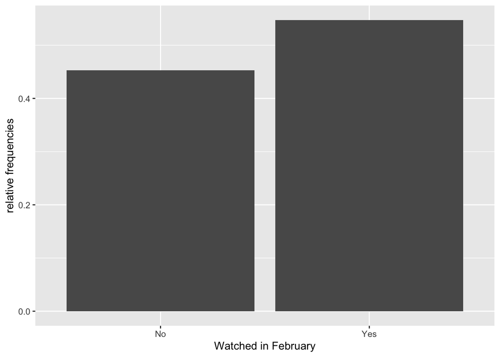

```r
#bar chart of defaults
def_vis1<-ggplot(data=userBasedData_clean, aes(x=watched_in_Feb)) +geom_bar(aes(y = (..count..)/sum(..count..))) + labs(x="Watched in February", y="relative frequencies")
def_vis1
```

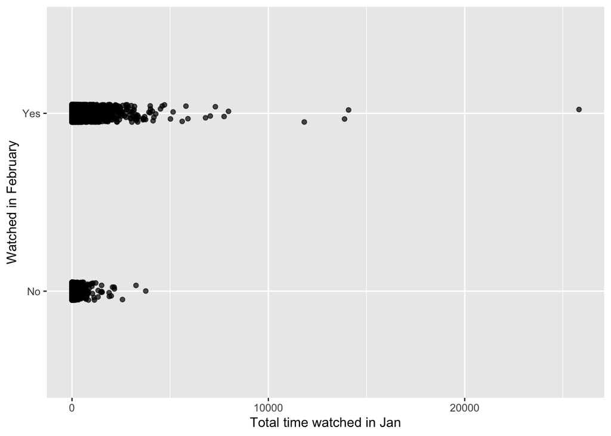

```r
def_vis2<-ggplot(data=userBasedData_clean, aes(y=watched_in_Feb,x=(total_Time)))  + labs(y="Watched in February", x="Total time watched in Jan")  +geom_jitter(width=0, height=0.05, alpha=0.7) #We use jitter to offset the display of defaults/non-defaults to make the data easier to interpert. We have also changed the amount to 1000$ to reduce the number of zeros on the horizontal axis.

def_vis2
```

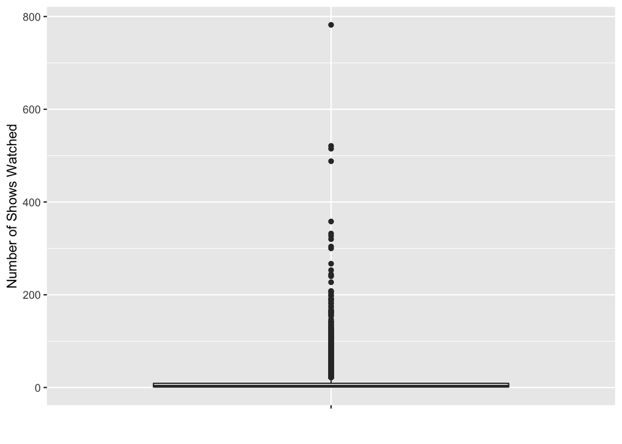

```r
ggplot(userBasedData_clean, aes(x="",y=noShows)) + geom_boxplot()+labs(x="", y= "Number of Shows Watched")
```

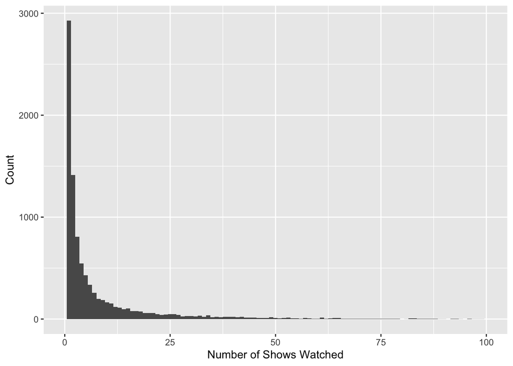

```r
ggplot(userBasedData_clean, aes(x=noShows)) +geom_histogram(binwidth=1)+xlim(0,100)+labs(x="Number of Shows Watched", y= "Count")
```

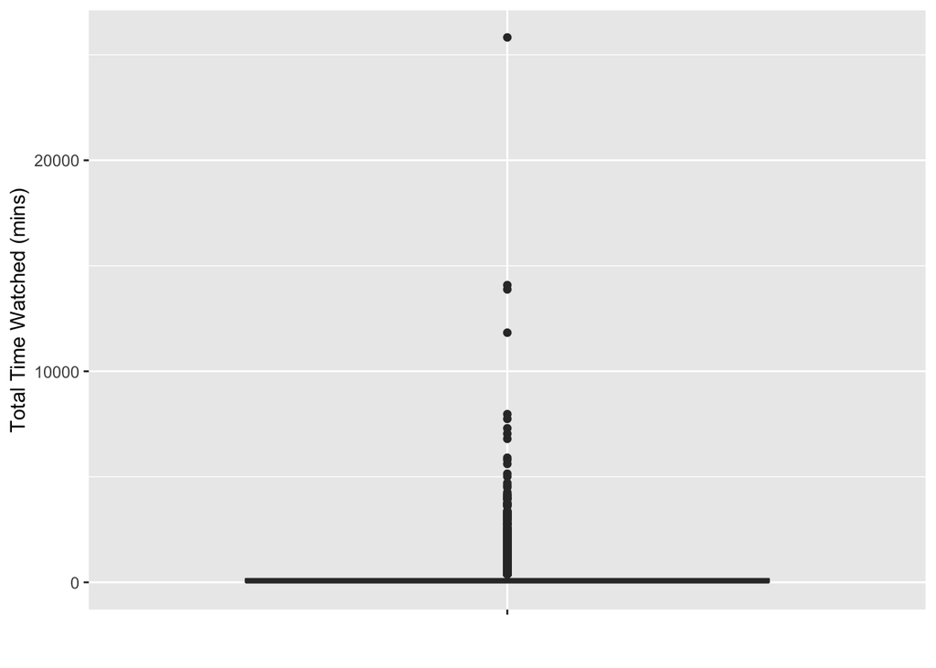

```r
ggplot(userBasedData_clean, aes(x="",y=total_Time)) + geom_boxplot()+labs(x="", y= "Total Time Watched (mins)")
```

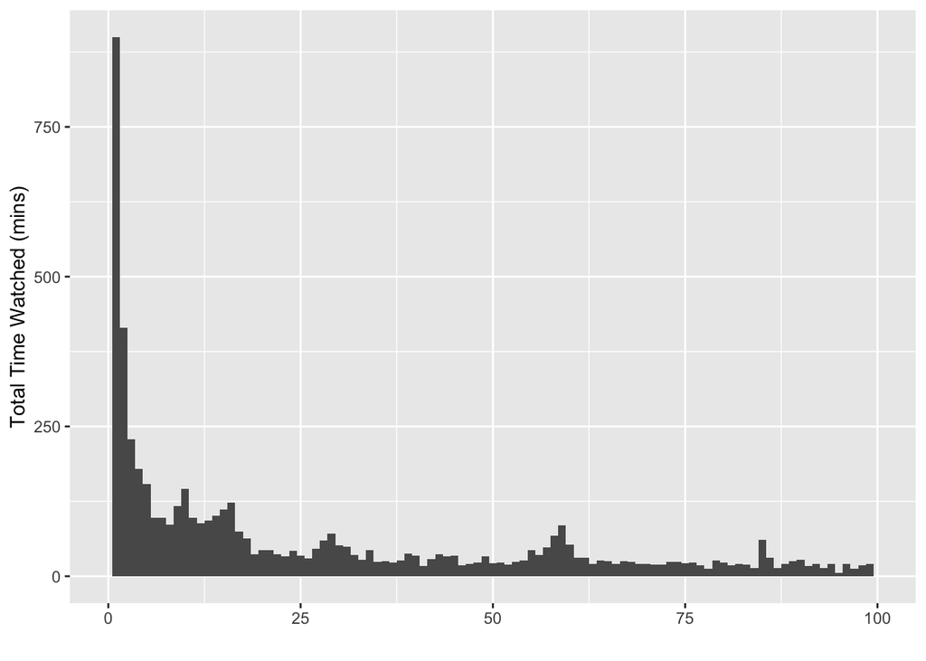

```r
ggplot(userBasedData_clean, aes(x=total_Time)) +geom_histogram(binwidth=1)+xlim(0,100)+labs(x="", y= "Total Time Watched (mins)")
```

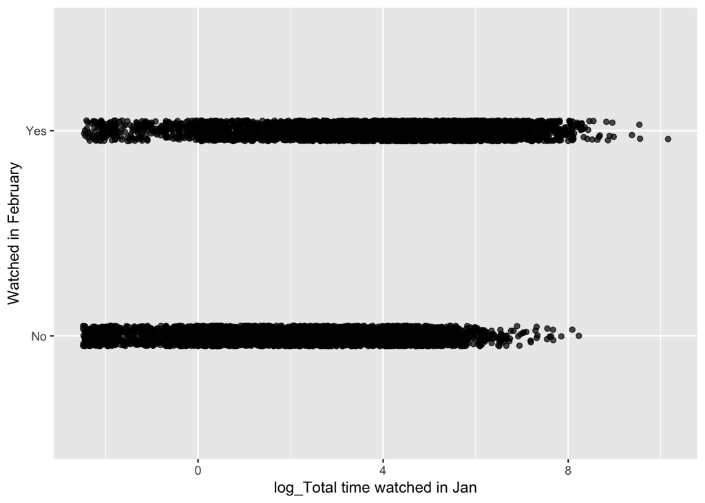

```r
def_vis3<-ggplot(data=userBasedData_clean, aes(y=watched_in_Feb,x=I(log(total_Time))))  + labs(y="Watched in February", x="log_Total time watched in Jan")  +geom_jitter(width=0, height=0.05, alpha=0.7) #We use jitter to offset the display of defaults/non-defaults to make the data easier to interpert. We have also changed the amount to 1000$ to reduce the number of zeros on the horizontal axis.

def_vis3
```

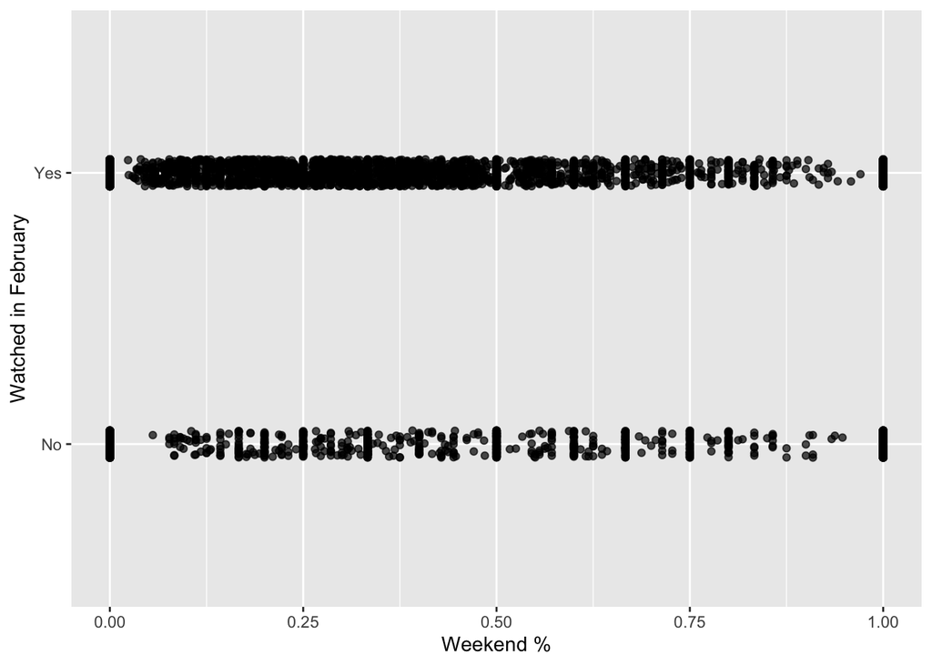

```r
def_vis4<-ggplot(data=userBasedData_clean, aes(y=watched_in_Feb,x=weekend))  + labs(y="Watched in February", x="Weekend %")  +geom_jitter(width=0, height=0.05, alpha=0.7) #We use jitter to offset the display of defaults/non-defaults to make the data easier to interpert. We have also changed the amount to 1000$ to reduce the number of zeros on the horizontal axis.

def_vis4
```

## 3.4 Data preparation

Also the total time watched and number of shows watched data are highly skewed. This might create problems for regression methods so I will log-transform them to reduce spread.

```r
userBasedData_clean<- userBasedData_clean %>%
  mutate(
    log_total_Time = log(total_Time), # log transform total time
    log_number_of_shows = log(noShows)
    ) %>%
    select(-total_Time,-noShows)


glimpse(userBasedData_clean)
```

```
## Rows: 9,351
## Columns: 22
## $ weekday             <dbl> 1.0000000, 1.0000000, 1.0000000, 0.0000000, 0.8709…
## $ weekend             <dbl> 0.0000000, 0.0000000, 0.0000000, 1.0000000, 0.1290…
## $ Afternoon           <dbl> 0.000, 0.000, 0.000, 0.000, 0.000, 0.000, 0.000, 0…
## $ Day                 <dbl> 0.00000000, 1.00000000, 1.00000000, 0.00000000, 0.…
## $ Evening             <dbl> 1.0000000, 0.0000000, 0.0000000, 1.0000000, 0.8064…
## $ Night               <dbl> 0.00000000, 0.00000000, 0.00000000, 0.00000000, 0.…
## $ Children            <dbl> 0, 0, 0, 0, 0, 0, 0, 0, 0, 0, 0, 0, 0, 0, 0, 0, 0,…
## $ Comedy              <dbl> 0.000000, 0.000000, 0.000000, 0.000000, 6.451613, …
## $ Drama               <dbl> 0.00000, 0.00000, 0.00000, 0.00000, 32.25806, 0.00…
## $ Entertainment       <dbl> 0.000000, 0.000000, 0.000000, 100.000000, 6.451613…
## $ Factual             <dbl> 0.00000, 0.00000, 0.00000, 0.00000, 41.93548, 0.00…
## $ Learning            <dbl> 0, 0, 0, 0, 0, 0, 0, 0, 0, 0, 0, 0, 0, 0, 0, 0, 0,…
## $ Music               <dbl> 0.000000, 0.000000, 0.000000, 0.000000, 6.451613, …
## $ News                <dbl> 100.000000, 100.000000, 100.000000, 0.000000, 3.22…
## $ NoGenre             <dbl> 0, 0, 0, 0, 0, 0, 0, 0, 0, 0, 0, 0, 0, 0, 0, 0, 0,…
## $ RelEthics           <dbl> 0.00, 0.00, 0.00, 0.00, 0.00, 0.00, 0.00, 0.00, 0.…
## $ Sport               <dbl> 0.000000, 0.000000, 0.000000, 0.000000, 3.225806, …
## $ Weather             <dbl> 0.00000, 0.00000, 0.00000, 0.00000, 0.00000, 0.000…
## $ per_al_Watched      <dbl> 50.00000, 0.00000, 0.00000, 0.00000, 22.58065, 100…
## $ watched_in_Feb      <fct> No, Yes, No, Yes, No, No, No, No, Yes, Yes, Yes, N…
## $ log_total_Time      <dbl> 2.81416243, -1.17010829, 0.62395786, 0.06167505, 6…
## $ log_number_of_shows <dbl> 0.6931472, 0.6931472, 0.6931472, 0.0000000, 3.4339…
```

Since this is a supervised learning task, let’s split the data into training and validation before we train our algorithms.

```r
library(rsample) #you have
set.seed(1212)

train_test_split <- initial_split(userBasedData_clean, prop = 0.75) #training set contains 75% of the data
# Create the training and testing datasets
combined_train <- training(train_test_split)
combined_test <- testing(train_test_split)
```

# 4 A logistic regression model

Let’s fit a logistic regression model for comparison purposes. I will fit a simple logistic regression model by using a subset of the variables, you can also try to improve the model with variable selection methods.

```r
# I will use 'glm' function but you can also use the 'caret' library.
# Also I will not use any variable selection methods but I will leave this to you as exercise
bbc_logreg_Fit<-glm(formula=watched_in_Feb  ~Day+log_total_Time+log_number_of_shows , data = combined_train,family = "binomial")
summary(bbc_logreg_Fit)
```

```
##
## Call:
## glm(formula = watched_in_Feb ~ Day + log_total_Time + log_number_of_shows,
##     family = "binomial", data = combined_train)
##
## Deviance Residuals:
##     Min       1Q   Median       3Q      Max
## -2.7590  -0.9110   0.3912   0.9125   1.8228
##
## Coefficients:
##                     Estimate Std. Error z value Pr(>|z|)
## (Intercept)         -1.12401    0.05269 -21.331  < 2e-16 ***
## Day                  0.06513    0.06920   0.941    0.347
## log_total_Time       0.13283    0.01823   7.288 3.14e-13 ***
## log_number_of_shows  0.74091    0.03926  18.873  < 2e-16 ***
## ---
## Signif. codes:  0 '***' 0.001 '**' 0.01 '*' 0.05 '.' 0.1 ' ' 1
##
## (Dispersion parameter for binomial family taken to be 1)
##
##     Null deviance: 9660.4  on 7012  degrees of freedom
## Residual deviance: 7896.4  on 7009  degrees of freedom
## AIC: 7904.4
##
## Number of Fisher Scoring iterations: 4
```

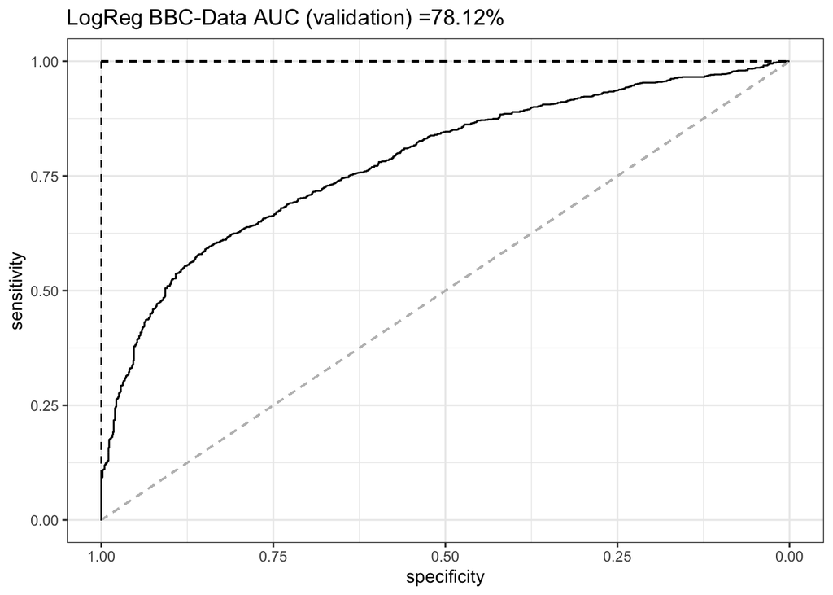

```r
# Next I predict the probabilities and then plot the ROC curve.
watched_prob<- bbc_logreg_Fit%>% predict(combined_test, type = "response")


library(pROC)
ROC_lr <- roc(combined_test$watched_in_Feb, watched_prob)
# Calculate the area under the curve (AUC)
AUC_lr<-round(auc(ROC_lr)*100, digits=2)
# Plot the ROC curve
ggroc(ROC_lr) + theme_bw()+ggtitle(paste("LogReg BBC-Data AUC (validation) =",AUC_lr,"%",sep = "")) +
geom_segment(aes(x = 1, xend = 0, y = 0, yend = 1), color="grey", linetype="dashed")+geom_segment(aes(x = 1, xend = 1, y = 0, yend = 1), color="black", linetype="dashed")+geom_segment(aes(x = 1, xend = 0, y = 1, yend = 1), color="black", linetype="dashed")
```

> Exercise: Improve the performance of the logistic regression model using tools you have learned in Data Science I. How much can you improve ROC?